# Quality analysis

Kaisu Hiltunen

2024-01-06

# Analysis of library quality

```r
library(ggplot2)
library(dplyr)
library(gridExtra)
library(knitr)
```

```r
setwd("~/R/meSIT_seq_and_scEpiAge_validation/quality_analysis/")
data_folder_path <- "Data"
```

This document summarises the three different libraries: Custom (S183), xGen Nextera (S184), and No Enrichment (S185). The libraries are compared in duplication rates, alignment rates and summarised in the end. For the Custom library more detailed analysis is performed and fastq screen and lambda duplication rates are shown.

# Custom library Lambda

## M-bias

In the M-bias plot it can be seen that the synthetic basepairs in the beginning of the reads are almost 100% methylated, as should be. The actual reads of lambda starting after the 10th bp are not methylated and this is very well reflected in the curve. The false positive bias is also decreasing towards the end of the read.

```r
selected_files <- "Data/bismark_mbias_Lambda_S183_R1.tsv"
# Read the data for Lambda control samples
Lambda_data<-read_mbias(selected_files)
# Plot M-bias using ggplot2
lambda_R1_plot <- plot_mbias(Lambda_data,"R1 CpGs", 1)+
  guides(color="none")+
  scale_color_manual(values =
                       c("#2978a0", "#710C32", "#fc8d62", "#68CBAC"))
```

There is no bias in the read 2.

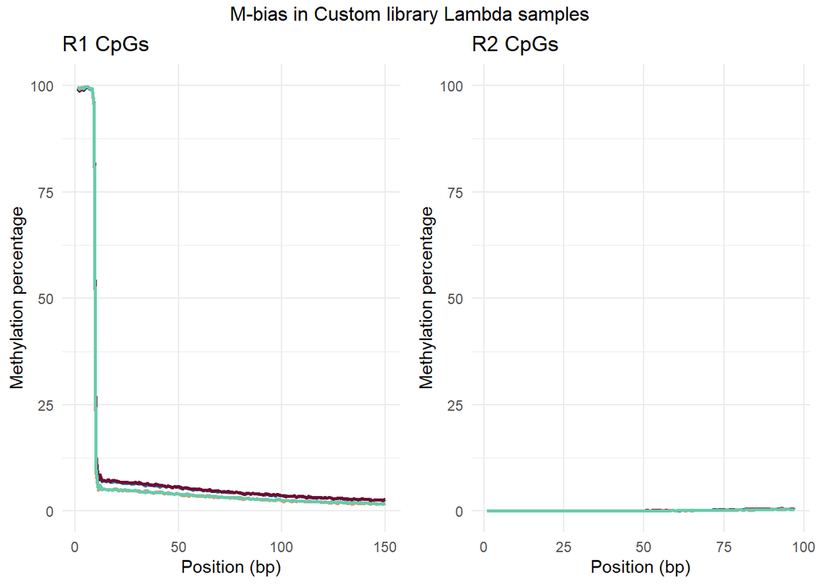

```r
# Combine plots and add a common title
combined_plot <- grid.arrange(lambda_R1_plot,
                              lambda_R2_plot,
                              ncol = 2,
                              top = "M-bias in Custom library Lambda samples")
```

Here is the M-bias of all samples in the custom enrichment library. The samples are marked in blue, and the mean and 0.25% and 0.75% quantiles are marked in black and green.

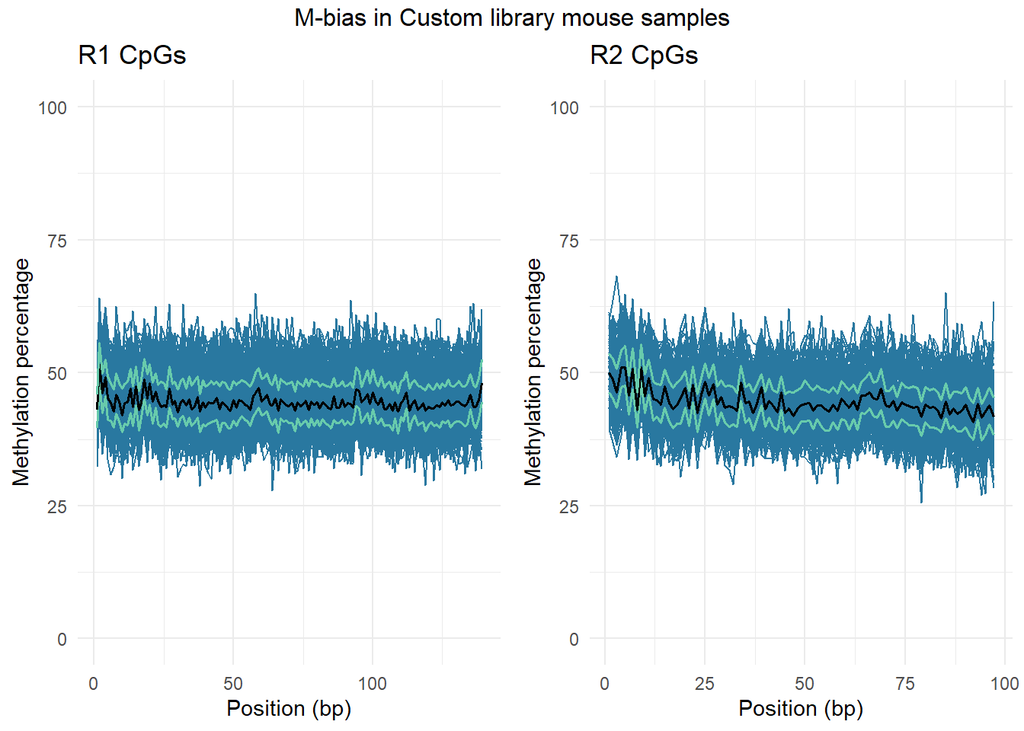

```r
# Combine plots and add a common title
combined_plot <- grid.arrange(S183_R1_plot,
                              S183_R2_plot,
                              ncol = 2,
                              top = "M-bias in Custom library mouse samples")
```

## Sample alignment in Custom library

Bismark is a widely used software tool for aligning bisulfite-treated DNA sequences to a reference genome, which is a critical step in DNA methylation analysis. The Bismark alignment rate refers to the percentage of reads that successfully align to a reference genome during the process of bisulfite sequencing data analysis. Aligned uniquely: The percentage of reads that align to a unique location in the reference genome.

Aligned ambiguously: The percentage of reads that align to multiple locations in the genome.

Did not align: The percentage of reads that do not align to the reference genome. This can happen due to various reasons, including sequencing errors, low-quality reads, or genomic regions that are difficult to map.

No genomic sequence: The percentage of reads that do not contain genomic sequence information. These reads may include technical artifacts, adapter sequences, or other non-genomic content.

High alignment rates, especially for uniquely aligned reads, are desirable as they indicate successful mapping of sequencing data to the reference genome.

```r
# First we load the alignment data which was exported from multiqc reports.
# Reports are in .tsv files and each library has four files.
# Here, the four files get merged into one .tsv per library
# and named merged_..._library_alignment.tsv

# Custom library aka S183
selected_files <- prepare_file_path("bismark_alignment_S183")
C_alignment_df <- read_alignment_files(
  selected_files, "merged_S183_library_alignment.tsv")
```

```
## [1] "Data/bismark_alignment_S183_qc1.tsv" "Data/bismark_alignment_S183_qc2.tsv"
## [3] "Data/bismark_alignment_S183_qc3.tsv" "Data/bismark_alignment_S183_qc4.tsv"
```

```r
# xGen library aka S184
selected_files <- prepare_file_path("bismark_alignment_S184")
X_alignment_df <- read_alignment_files(
  selected_files, "merged_S184_library_alignment.tsv")
```

```
## [1] "Data/bismark_alignment_S184_qc1.tsv" "Data/bismark_alignment_S184_qc2.tsv"
## [3] "Data/bismark_alignment_S184_qc3.tsv" "Data/bismark_alignment_S184_qc4.tsv"
```

```r
# No enrichment library aka S185
selected_files <- prepare_file_path("bismark_alignment_S185")
N_alignment_df <- read_alignment_files(
  selected_files, "merged_S185_library_alignment.tsv")
```

```
## [1] "Data/bismark_alignment_S185_qc1.tsv" "Data/bismark_alignment_S185_qc2.tsv"
## [3] "Data/bismark_alignment_S185_qc3.tsv" "Data/bismark_alignment_S185_qc4.tsv"
```

The Custom library mouse samples show very homogeneous alignment rates across samples.

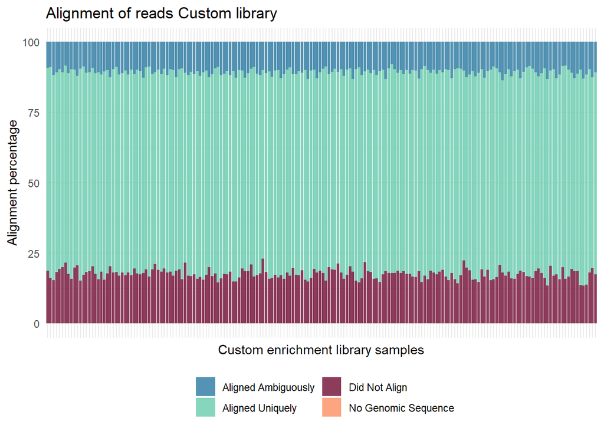

Statistics of Custom library mouse samples.

| Alignment type | Average alignment % | Std. Dev |
| --- | --- | --- |
| Aligned Uniquely | 72 | 2.2 |
| Aligned Ambiguously | 11 | 1.2 |
| Did Not Align | 18 | 1.8 |
| No Genomic Sequence | 0.00012 | 0.00058 |
| Total reads before alignment | 100 | 0 |

### Comparison of libraries

Comparing the Custom, xGen Nextera, and control library alignment rates with a boxplot.

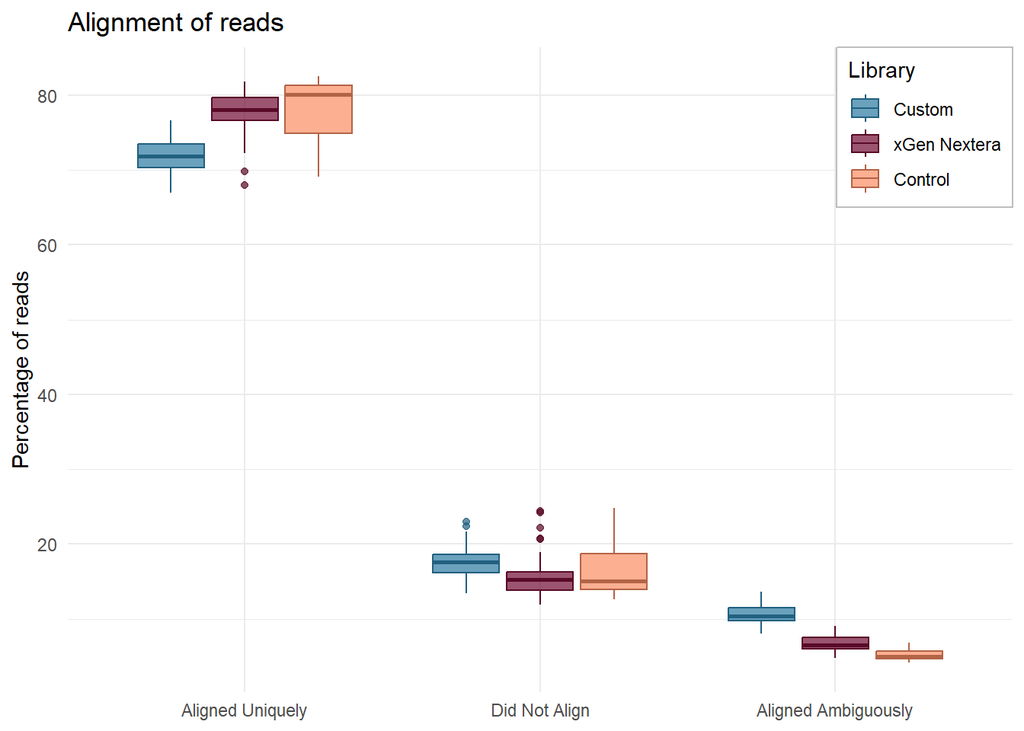

## Analysis of duplication rate

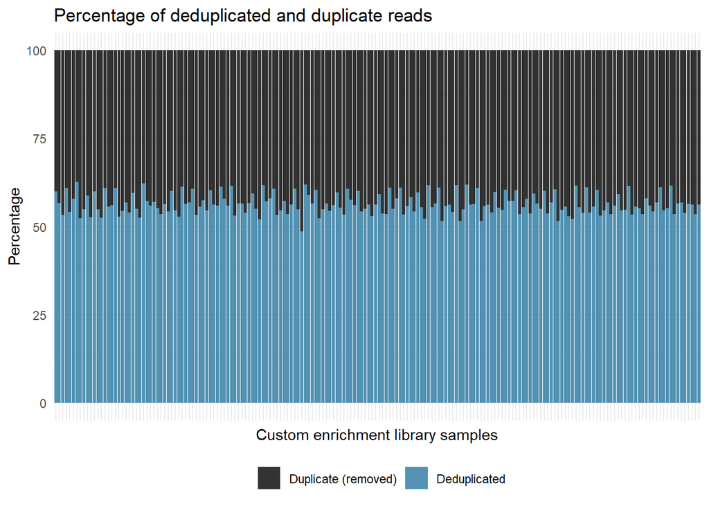

```r
plot_dedups(S183_deduplication_df, "Custom")
```

```r
#plot_dedups(S184_deduplication_df, "xGen Nextera")
#plot_dedups(S185_deduplication_df, "No enrichment")
```

## Comparison of library duplication rates

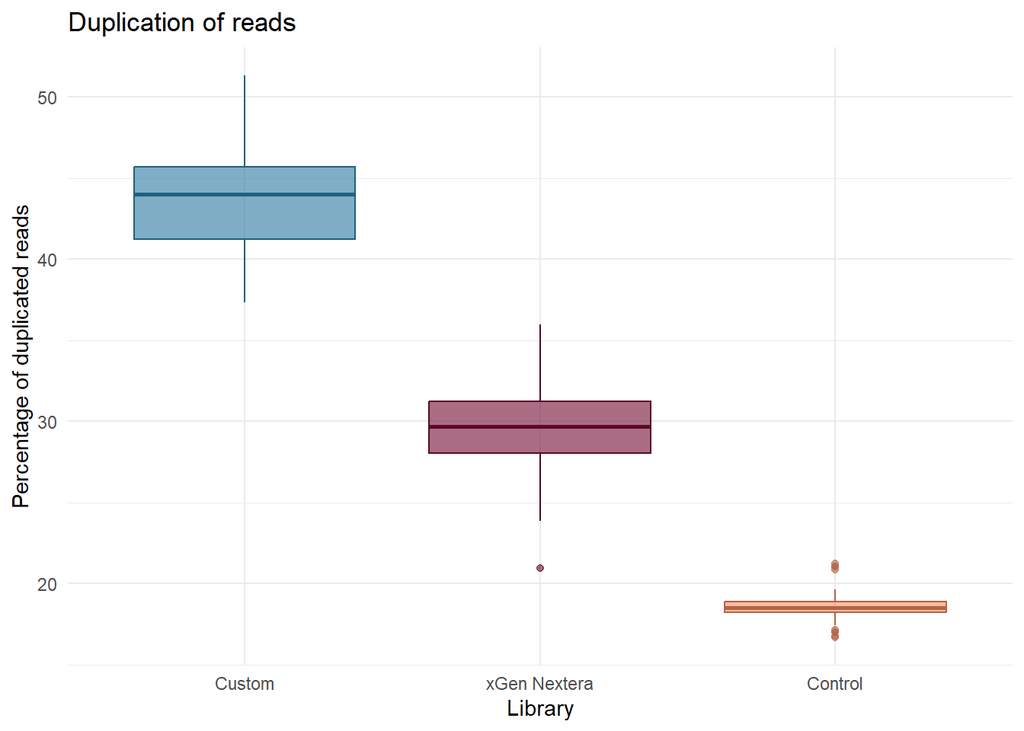

```
## Average deduplicated reads percentage in sample reads: 56.46 %
```

```
## Standard deviation in sample reads: 2.91 %
```

```r
selected_files <- prepare_file_path("bismark_deduplication_S183_lambda")
S183_lambda_dedup_df <- read_deduplication_files(
  selected_files,
  "merged_S183_library_deduplication_lambda.tsv", bind=TRUE)
```

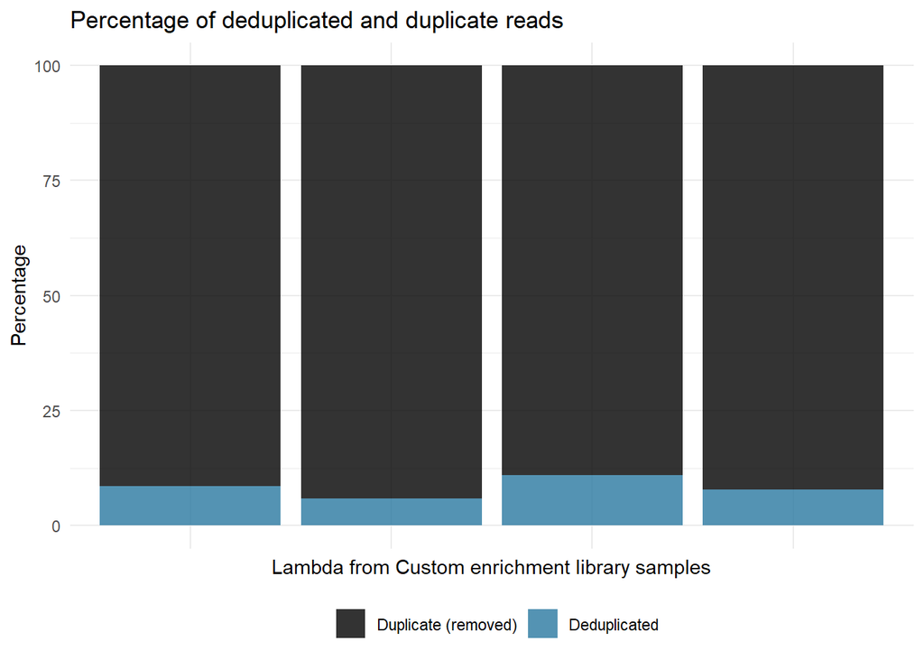

```
## Average deduplicated reads in custom library lambda control: 8.29 %
```

```
## Standard deviation: 2.08 %
```

```r
plot_dedups(S183_lambda_dedup_df, "Lambda from Custom")
```

## Alignment to various genomes

Here the alignments to different sequences are illustrated.

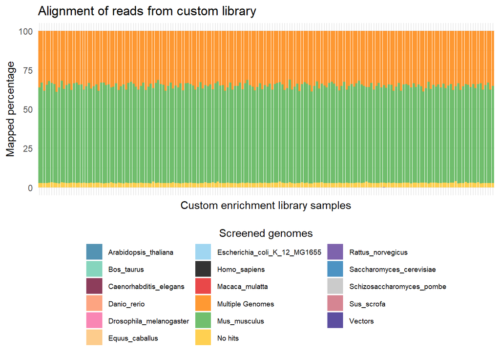

| Sequence set | Average alignment % | Std. Dev |
| --- | --- | --- |
| Mus_musculus | 62 | 1.8 |
| Rattus_norvegicus | 0.018 | 0.0073 |
| Danio_rerio | 0.0037 | 0.0025 |
| Homo_sapiens | 0.0017 | 0.0022 |
| Macaca_mulatta | 0.0011 | 0.0013 |
| Sus_scrofa | 0.00097 | 0.0013 |
| Bos_taurus | 0.00092 | 0.0016 |
| Caenorhabditis_elegans | 0.00081 | 0.0013 |
| Saccharomyces_cerevisiae | 0.00044 | 0.00087 |
| Drosophila_melanogaster | 0.00036 | 0.00075 |
| Arabidopsis_thaliana | 0.00025 | 6e-04 |
| Equus_caballus | 0.00043 | 8e-04 |
| Escherichia_coli_K_12_MG1655 | 7.5e-05 | 0.00049 |
| Vectors | 7.3e-05 | 4e-04 |
| Schizosaccharomyces_pombe | 0.00022 | 0.00098 |
| Multiple Genomes | 35 | 1.8 |
| No hits | 2.9 | 0.22 |

```r
# Filter files containing "fastq_screen" in their names
selected_files <- prepare_file_path("fastq_screen")
S183_fastq_df <- read_fastq_files(selected_files,
                                  "merged_custom_library_align_categories.tsv")
plot_fastq_screen(S183_fastq_df, "from custom library")
```